# Analysis of Human Movement via Wearable Devices

David Samson

October 22, 2015

## Introduction

This assignment concerns tracking human movement via wearable devices. 6 devices were attached to the body and dumbbell of men who were asked to perform barbell lifts, both correctly and incorrectly. Each man was identified. (The devices included an acceleromter, a gyroscope and a magnetometer.) The objective was learn the characteristics of movement in the training set, and apply it to a subsequent testing set.

### Source

The data was created by Ugulino, W.; Cardador, D.; Vega, K.; Velloso, E.; Milidiu, R.; Fuks, H. and can be found here: http://groupware.les.inf.puc-rio.br/har#ixzz3pW8icq8w

## EDA

The training data contains 160 variables. To reduce the amount of data to be processed, we eliminated the following types:

| Data Type | Usage |
| --- | --- |
| Timestamp | Not relevant for future test sets |
| Summary Data(such as min, max, std) | Discarded, as not sufficiently granular and derived. |

We were then left with 50 variables. We then used Primary Component Analysis to further reduce to a minimal number of key variables:

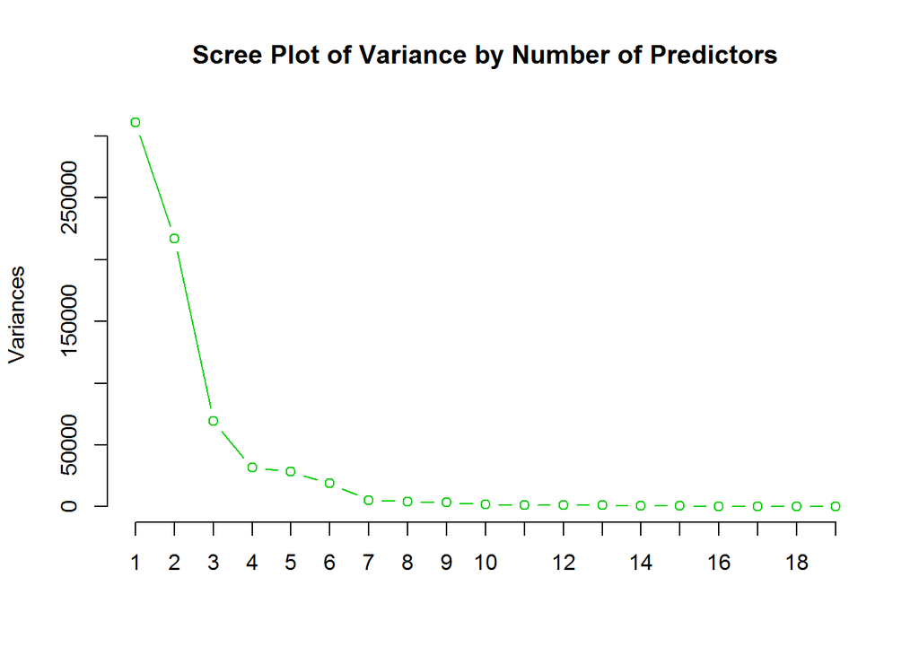

[figure not shown]

```r
prcomp <- prcomp(training[,3:32])
screeplot(prcomp, type="lines",col=3,npcs=19, main="Scree Plot of Variance by Number of Predictors")
```

## Model Selection

Models such as the Generalized Linear Model and Blackboost could not be used as they only test for 2-class outcomes.

We tested the following models:

| Model | Accuracy | Execution Time (secs) |
| --- | --- | --- |
| Linear Discriminant Analysis(lda) | 60.04% | 7.74 |
| Naive Bayes(nb) | 59.99% | 2171.86 |
| Random Forest (rf) | 99.15% | 36.72 |

The above led us clearly to proceed with a Random Forest model.

## Model Tuning

In analyzing the RF model, we calculated the accuracy of various numbers of trees. There was very little difference between 500 trees (99.146% accurate) versus 5000 trees (99.154% accurate). So we proceeded with 500 trees.

```r
result500 <- randomForest(classe~.,data=training, ntrees=500)
```

## Cross validation and Out of Sample Error Rate

As per http://www.stat.berkeley.edu/~breiman/RandomForests/cc_home.htm#ooberr, “In random forests, there is no need for cross-validation or a separate test set to get an unbiased estimate of the test set error. It is estimated internally, during the run.” As stated above, the accuracy was 99.15%.

The calculated Out of Sample Error Rate (as per the randomforest function) is 0.79%.